# P6_Chadeau_notebook7_quanti_quali_age_categ

```python
from IPython.core.display import display, HTML
f = open("P6_Chadeau_notebook7_sommaire.html", "r", encoding="utf-8")
display(HTML(f.read()))
```

TOP  
Importation des librairies et fichiers  
Déclaration des fonctions  
Importation dataframe  
La mission

- Analyse des corrélations

- Corrélation entre l'âge des clients et la catégorie des achats

# Projet 6 -Analysez les ventes d'une librairie avec R ou Python

[figure not shown]

### Importation des librairies et fichiers

```python
import pandas as pd
import numpy as np
import re
import matplotlib.pyplot as plt
import seaborn as sns
import datetime
from statsmodels.tsa.stattools import adfuller
from scipy.stats import chi2_contingency
import scipy.stats as st
import statsmodels.api as sm
from scipy.stats import linregress
import scipy.stats as st
import statsmodels.api as sm
import math
import statsmodels.formula.api as smf
from statsmodels.formula.api import ols
from scipy.stats import shapiro
from scipy.stats import ks_2samp

#Permet d'afficher toutes les lignes d'une liste
pd.set_option("max_rows", None)

#Permet l'affichage de tous les résultats d'une cellule (pas seulement le dernier)
from IPython.core.interactiveshell import InteractiveShell
InteractiveShell.ast_node_interactivity = "all"

#Permet de définir des paramètres d'affichage pour l'ensemble des graphiques
from pylab import rcParams
rcParams['figure.figsize'] = 15,5
```

### Déclaration des fonctions

### Importation dataframe

```python
#Import du fichier 'join_final', jointure des 3 dataframes customers, products et transactions

df=pd.read_csv("join_final.csv")
df['date']= pd.to_datetime(df['date'],errors = 'coerce')
df['birth']=df['birth'].astype('Int64')
df['Age']=df['Age'].astype('Int64')
df['mois']=df['date'].dt.month
#Le dataframe est indexé sur la colonne 'date' afin de pouvoir travailler sur la série temporelle
#en terme de période
df.set_index('date', inplace=True)
```

```python
#Import du fichier 'customers_clean'
df_customers_clean=pd.read_csv("customers_clean.csv")
df_customers_clean['Age']=2022-df_customers_clean['birth']
```

## Partie 3 - La mission (suite)

### Analyse des corrélations

### **Corrélation entre l'âge des clients et la catégorie des achats**

Il s'agit d'analyser la corrélation **entre 1 variable quantitative (l'âge) et 1 variable qualitative (la catégorie).**  
Afin de définir la corrélation entre ces 2 types de variables, on peut utiliser la méthode d'analyse **ANOVA à 1 facteur** (=1 variable qualitative) avec :

- variable dépendante (VD) = variable quantitative = l'âge
- variable indépendante (VI) = le facteur = la catégorie  
  On va réaliser l'analyse de la dépendance de la variable quantitative "âge" au facteur qualitatif "catégorie".  
  On crée d'abord le dataframe qui servira à notre analyse :

```python
#Création dataframe
df_corrige=df.copy()
df_corrige=df_corrige.loc[(df_corrige['client_id']!='c_1609')&(df_corrige['client_id']!='c_6714')&\
                          (df_corrige['client_id']!='c_3454')&(df_corrige['client_id']!='c_4958')]
df1=df_corrige.fillna(0)
df1['Age']=df1['Age'].astype('int64')
df_age_categ=df1.reset_index()
```

Avant de faire le test, on affiche la distribution des âges par catégorie et on affiche la moyenne des âge dans chaque catégorie.

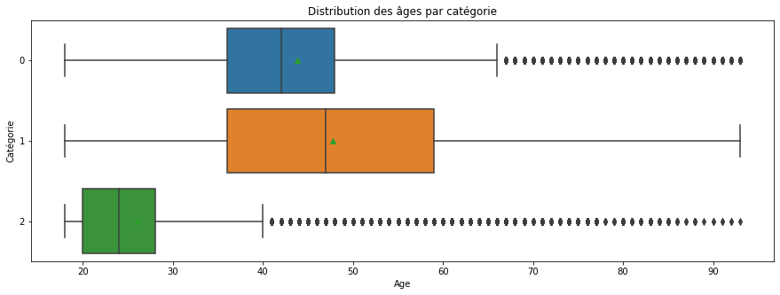

```
Moyenne par catégorie
----------------------
```

```
categ
0    43.794563
1    47.802913
2    25.965508
Name: Age, dtype: Float64
```

```python
memo=sns.boxplot(data=df_corrige, x='Age', y='categ', orient='h', showmeans=True)
memo=plt.title('Distribution des âges par catégorie')
memo=plt.xlabel("Age")
memo=plt.ylabel("Catégorie")
memo=plt.show()


# Calcul moyenne des prix par catégorie
print("Moyenne par catégorie")
print("----------------------")
df_corrige.groupby('categ').mean()['Age']
```

On constate :

les moyennes des catégories 0 et 1 sont assez proches

la moyenne de la catégorie 2 se détache et est beaucoup plus basse que les 2 autres

Il faut le vérifier au travers de la réalisation de test et vérifier si la différence est significative.  
On va donc poser les 2 hypothèses :  
* H0 = les 3 moyennes sont égales  
* H1 = au moins 1 moyenne est différente des 2 autres

**L'ANOVA est basée sur les tests de Fisher** qui permet de tester l'égalité des moyennes  
Après avoir effectué le test, récupération de la p_value :

```python
model = ols('Age ~ categ', data=df_age_categ).fit()
print(model.summary())
anova_table = sm.stats.anova_lm(model, typ=2)
anova_table
```

```
                            OLS Regression Results
==============================================================================
Dep. Variable:                    Age   R-squared:                       0.007
Model:                            OLS   Adj. R-squared:                  0.007
Method:                 Least Squares   F-statistic:                     4525.
Date:                Thu, 17 Feb 2022   Prob (F-statistic):               0.00
Time:                        11:31:59   Log-Likelihood:            -2.5574e+06
No. Observations:              632477   AIC:                         5.115e+06
Df Residuals:                  632475   BIC:                         5.115e+06
Df Model:                           1
Covariance Type:            nonrobust
==============================================================================
                 coef    std err          t      P>|t|      [0.025      0.975]
------------------------------------------------------------------------------
Intercept     45.0814      0.022   2085.731      0.000      45.039      45.124
categ         -1.9722      0.029    -67.267      0.000      -2.030      -1.915
==============================================================================
Omnibus:                    44637.430   Durbin-Watson:                   0.853
Prob(Omnibus):                  0.000   Jarque-Bera (JB):            54701.818
Skew:                           0.698   Prob(JB):                         0.00
Kurtosis:                       3.353   Cond. No.                         2.14
==============================================================================

Notes:
[1] Standard Errors assume that the covariance matrix of the errors is correctly specified.
```

|  | sum_sq | df | F | PR(>F) |
| --- | --- | --- | --- | --- |
| categ | 8.615619e+05 | 1.0 | 4524.844717 | 0.0 |
| Residual | 1.204276e+08 | 632475.0 | NaN | NaN |

Comme p_value= 0 < 0,05 alors on peut rejeter l'hypothèse H0 selon laquelle les moyennes des 3 catégories sont égales.  
On en déduit que **le choix de la catégorie est probablement influencé par l'âge.**

F est important ce qui implique que les moyennes des groupes sont assez écartées les unes des autres.

**==>Confirmation avec calcul de Eta carré**

```python
X = df_age_categ['categ'] # qualitative
Y = df_age_categ['Age'] # quantitative

def eta_squared(x,y):
    moyenne_y = y.mean()
    classes = []
    for classe in x.unique():
        yi_classe = y[x==classe]
        classes.append({'ni': len(yi_classe),
                        'moyenne_classe': yi_classe.mean()})
    SCT = sum([(yj-moyenne_y)**2 for yj in y])
    SCE = sum([c['ni']*(c['moyenne_classe']-moyenne_y)**2 for c in classes])
    return SCE/SCT

print('Eta squared : ',round(eta_squared(X,Y),2))
```

```
Eta squared :  0.11
```

Le coefficient η² montre une faible corrélation entre l'âge des clients et la catégorie d'achat. Les clients les plus jeunes vont essentiellement se tourner vers l'achat de catégorie 2 alors que les autres catégories de produits vont être achetées par tout type de clients.

**==>Tests pré-requis ANOVA**

**1. L'indépendance entre les échantillons de chaque groupe**  
Elle est donnée par le contexte de l'étude : il s'agit de l'analyse de 3 catégories distinctes de livres (0, 1 et 2)

**1ère condition validée.**

**2. L’égalité des variances (homoscédasticité)**  
On la réalise via le test de Bartlett.

```python
df_age_categ.groupby("categ")['Age'].agg('var')
```

```
categ
0    132.620783
1    249.434712
2     98.007304
Name: Age, dtype: float64
```

On voit que les variances sont différentes entre les 3 groupes mais le test de bartlett nous permettra de tester si les variances sont significativement différentes ou non.  
On pose :  
* H0 : Les variances de chaque groupe sont égales si p-value > 5%  
* H1 : Les variances de chaque groupe ne sont pas toutes égales < 5%

```python
st.bartlett(df_age_categ.Age[df_age_categ.categ == 0],
            df_age_categ.Age[df_age_categ.categ == 1],
            df_age_categ.Age[df_age_categ.categ == 2])
```

```
BartlettResult(statistic=32997.704732693834, pvalue=0.0)
```

Comme la p_value < 5% alors on peut rejeter l'hypothèse nulle et on peut dire que les variances de chaque groupe ne sont probablement pas toutes égales.  
**La 2ème condition n'est donc pas validée.**

**3. Normalité des résidus**  
L’objectif est de s’assurer que les résidus suivent une loi normale  
On utilise le **test de Shapiro-Wilk** pour tester la normalité des résidus.  
On pose :  
H0 : Les résidus suivent une loi normale si p-value > 5%  
H1 : Les résidus ne suivent pas une loi normale si p-value < 5%

```python
model = ols('Age ~ categ', data=df_age_categ).fit()
shapiro(model.resid)
```

```
ShapiroResult(statistic=0.9671370983123779, pvalue=0.0)
```

Le test de Shapiro étant limité à un échantillon de 5000, il faut prendre un autre test pour démontrer la normalité de la distribution :  
**test Kolmogorov-Smirnov** avec les mêmes hypothèses.

```python
st.kstest(model.resid, 'norm')
```

```
KstestResult(statistic=0.4942969062530741, pvalue=0.0)
```

Comme p_value < 5% alors on rejette H0 : les résidus ne suivent pas une loi normale  
**3ème condition non validée.**

**==>Les conditions du test n'étant pas valides, il faut utiliser une autre méthode que ANOVA qui n'est pas fiable, un test non paramétrique qui ne prend pas en compte une loi de distribution des données : "Kruskal-Wallis"**  
Ce test ne travaille plus sur la moyenne mais sur la position des points sur l'axe : on remplace les valeurs par leur rang.  
On pose :  
H0 : même rang moyen pour chaque groupe si p-value > 5%  
H1 : au moins 2 groupes ont des rangs moyens différents si p-value < 5%

```python
X = df_age_categ['categ'] # qualitative
Y = df_age_categ['Age'] # quantitative
st.kruskal(Y[X==0],Y[X==1],Y[X==2])
```

```
KruskalResult(statistic=72209.48289794501, pvalue=0.0)
```

La p-value étant < 5% alors **on rejette H0 : au moins une des 3 catégories diffère des autres, sa distribution n'est pas égale.**  
On en déduit donc que **le choix de la catégorie est probablement influencé par l'âge.**